# praca domowa 5

Joanna Gajewska

29 April 2019

# Polecenie

Artykuł https://arxiv.org/pdf/1802.09596.pdf proponuje domyślne hiperparametry dla konstrukcji drzew. Na zbiorze danych Titanic

*a)*sprawdź skuteczność modelu z podanymi hiperparametrami (po zapoznaniu się z ich znaczeniem),

*b)*porównaj wynik z domyślnymi hiperparametrami z pakietu i z wynikiem random search,

*c)*narysuj najlepsze otrzymane drzewo, wyciągnij z niego reguły decyzyjne,

*d)*dla domyślnych hiperparametrów z artykułu porównaj drzewa zbudowane z kryterium podziału Gini i Information Gain (np. parms = list(split = ‘information’)).

### a) sprawdź skuteczność modelu z podanymi hiperparametrami (po zapoznaniu się z ich znaczeniem)

Oto dataset na którym będą prowadzone badania w tym zadaniu. Dotyczy on pasażerów słynnego Titania. Ma posłużyć do przewidywania , którzy pasażerowie mają sznasę przeżyć.

```
##   PassengerId Survived Pclass    Sex      Age SibSp Parch    Fare Embarked
## 1           1        0      3   male 22.00000     1     0  7.2500        S
## 2           2        1      1 female 38.00000     1     0 71.2833        C
## 3           3        1      3 female 26.00000     0     0  7.9250        S
## 4           4        1      1 female 35.00000     1     0 53.1000        S
## 5           5        0      3   male 35.00000     0     0  8.0500        S
## 6           6        0      3   male 29.69912     0     0  8.4583        Q
```

```
## acc.test.mean
##     0.7946017
```

Powyżej jest wyświetlona skuteczność dla drzewa decyzyjnego z ustawionymi parametrami z artykułu.

### b) porównaj wynik z domyślnymi hiperparametrami z pakietu i z wynikiem random search

```
##               ACC_article ACC_default ACC_ranodm
## acc.test.mean   0.7946017   0.8080911  0.7935032
```

Analizując tabelę z wynikami ACC, widać, że najlepsze wyniki otrzymani dla domyślnych parametrów. Jednak są to na tyle znikome różnice, że mogą się zmieniać, ze względu na wykonywaną kroswalidacje przy wyliczaniu skuteczności.

### c) narysuj najlepsze otrzymane drzewo, wyciągnij z niego reguły decyzyjne,

Drzewo rysowane dla domyślnych parametrów.

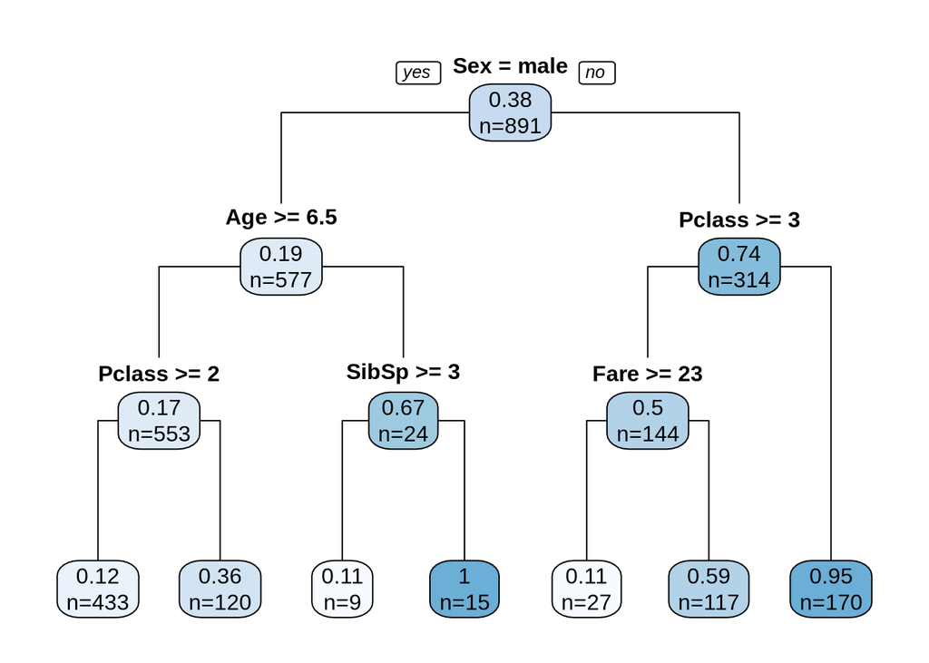

```
##
## Regression tree:
## rpart(formula = Survived ~ ., data = train)
##
## Variables actually used in tree construction:
## [1] Age    Fare   Pclass Sex    SibSp
##
## Root node error: 210.73/891 = 0.23651
##
## n= 891
##
##         CP nsplit rel error  xerror     xstd
## 1 0.295231      0   1.00000 1.00233 0.016056
## 2 0.073942      1   0.70477 0.70745 0.033208
## 3 0.027124      2   0.63083 0.63433 0.031692
## 4 0.026299      3   0.60370 0.59875 0.032096
## 5 0.023849      4   0.57740 0.59222 0.032189
## 6 0.021091      5   0.55356 0.57670 0.032626
## 7 0.010000      6   0.53246 0.56222 0.032517
```

Z diagramu można zauważyć, że takie cechy jak płeć, wiek i klasa odgrywały kluczową rolę w klasyfikacji.

W powyższej tabeli zawarte są informacje parametru cp( współczynnik złożności, im większy tym mniej liści w drzewie, gdy cp=0 przeuczone drzewo), liczby podziałów drzewa, względnego błędu powtórnego podstawienia , względnego błędu kroswalidacji i odchylenie standardowe dla ostatniego przypadku. Przedstawione wartosci cp, są wartościami progowymi, dla których następuje zmiana budowy drzewa. Dla otrzymanego drzewa liczba liści wynosi 7, a cp=0.01

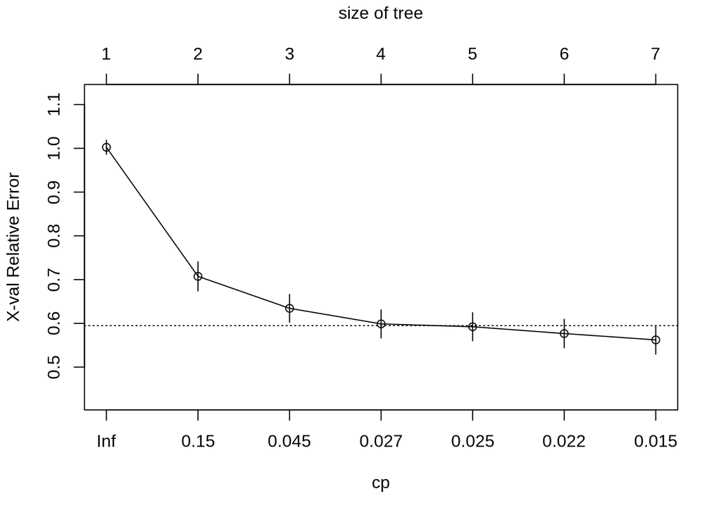

Powyżej jest wykres zależności względnego blędu kroswalidacji od wartości współczynnika cp. Widać im mniejszy błąd tym lepszą predykcje można usyskać, jednak trzeba rozsądnie wybierać współczynnik cp, tak by nie byl za mały, gdyż drzewo można przeuczyć. W tym przypadku ilość liści zdecydowanie nie jest niebeziecznie za duża, więc jak najbardziej można zaakceptować otrzymany wynik.

### d) dla domyślnych hiperparametrów z artykułu porównaj drzewa zbudowane z kryterium podziału Gini i Information Gain (np. parms = list(split = ‘information’)).

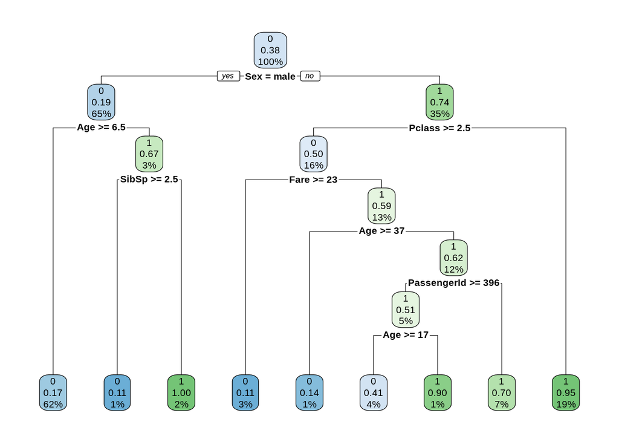

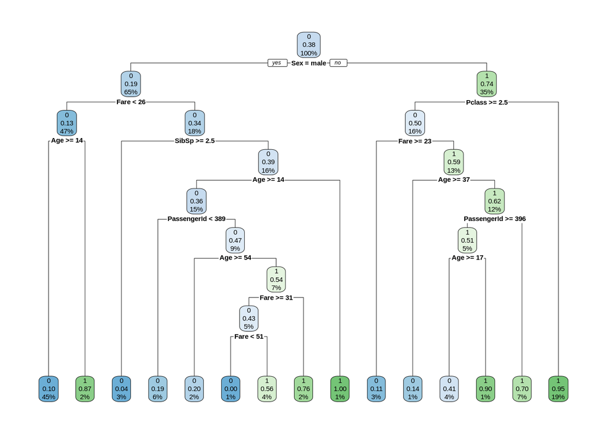

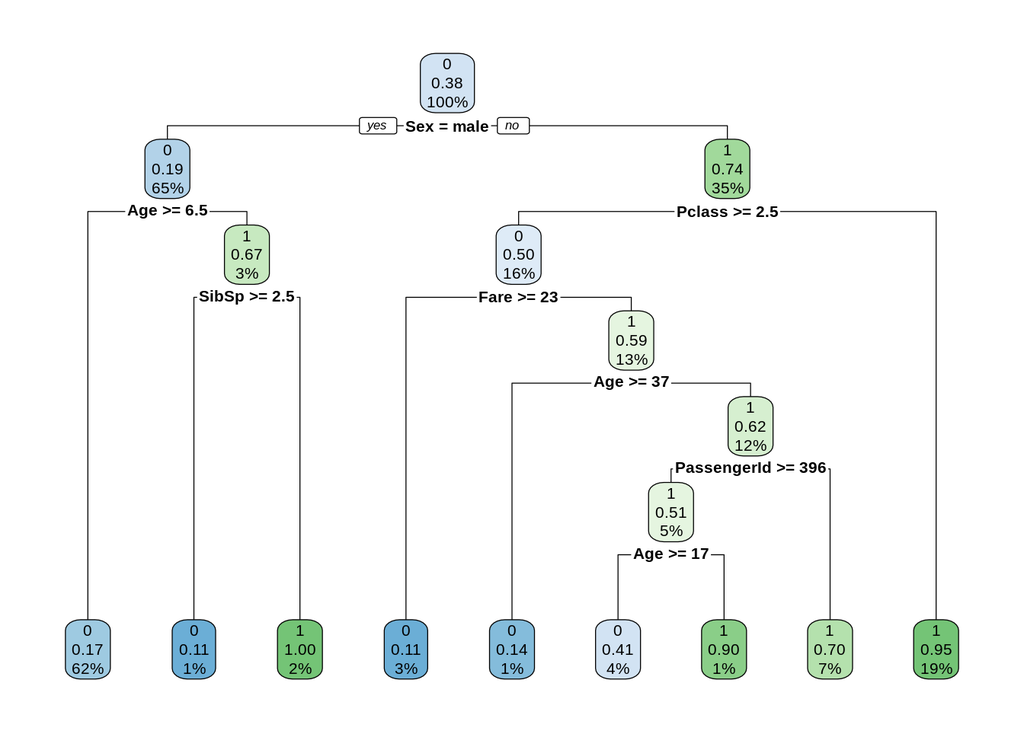

Wykresy które nam się wyświetlają są w kolejnośći : hiperparametry domyślne z artykułu, kryterium podziału Information gain oraz kryterium podziału Gini. Diagramy dla gini oraz hiperparametrów z artykułu są identyczne, kryteria wyboru są takie same, oraz ilość liści wynosi 9. Dla przypadku information gain drzewo ma o wiele więcej liści - 15, co może grozić przeuczeniem.